# フィッティングと接続：ボルト締めおよびリベット留め

## D1.19 リベット材料

航空機産業においてアルミニウム合金が圧倒的に最も広く使用されている材料であるため、リベット用材料としてもアルミニウム合金が最も広く使用されている。 表D1.5（第1列）は、リベットに使用される5つのアルミニウム合金と、各材料の極限せん断応力 $F_{su}$ を示している。 2017-T3 ( $F_{su} = 34000$ ) および 2024-T31 ( $F_{su} = 41000$ ) で作られたリベットは、熱処理直後、または時効硬化が起こる前に打鋲しなければならないリベットである。 熱処理後にリベットを冷蔵保管することで、時効や硬化を遅らせることができる。 その他のリベット材料は、時効状態でもそれほど硬くなく、脆性も低いため、空気中に保管していつでも打鋲することができる。 これらのいわゆる軟質リベットはせん断強度が低いが、航空機構造の大部分は薄板で構成されているため、支圧が限界になることが多く、したがってリベットのせん断は限界にならない。 ほとんどの表面または外板のリベット留めには、通常 2117-T3 ( $F_{su} = 30000$ ) などの軟質リベットが使用される。

## D1.20 リベットの強度（丸頭・皿頭突出型）

リベットは、2つ以上の構造部材を締結または結合するために、航空機構造で広く使用されている。 リベット接合部の応力解析の標準的な方法では、主に2つの破壊形式、すなわちリベット軸部のせん断破壊、およびリベットが接続する薄板またはプレートに押し付けられる箇所での金属の支圧（または圧縮）破壊を考慮する。

図D1.28は、あるプレートから別のプレートへ荷重を伝達する際に、リベットに作用する主な力を示している。 荷重は、プレートの支圧作用によってプレートからリベットへ伝達される。 その後、荷重はリベットに沿って伝達され、もう一方のプレートにおける支圧作用によって抵抗される。 リベットに対するプレートの支圧力が同一直線上にないため、これらの力はリベットをせん断および曲げようとする。 中間にフィラープレートがない場合、通常、リベットの曲げは無視される。 図D1.28(a)ではリベットは単一せん断（単面せん断）状態にあり、図D1.28(b)ではダブルせん断（両面せん断）状態にある。

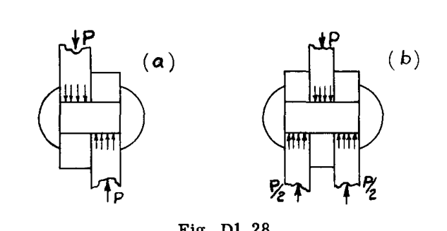

図 D1.28

リベットの極限せん断強度は、次の式で与えられる：

$$P_a = F_{su} A n$$
—(17)

ここで、 * $P_a$ = リベットの極限せん断強度 (lbs.) * $F_{su}$ = リベットの極限許容せん断応力 (psi) * $A$ = リベット断面積 = $\pi D^2 / 4$ （ここで $D$ は公称リベット穴径に等しい） * $n$ = リベット1本あたりのせん断マニホールドの数

文献(17)は、突出頭アルミニウム合金リベットのせん断強度が、 $D/t$ （板厚に対するリベット径）比の増加によって影響を受けることを示している。 文献(17)の結論は以下の通りである：

### 単一せん断（単面せん断）のリベット：

$D/t$ の値が3以下の場合：
$$\text{単一せん断強度} = \text{基本許容単一せん断強度}$$

$D/t$ の値が3より大きい場合：
$$\text{単一せん断強度} = \text{基本許容単一せん断強度} \times \left[ 1 -
0.04 (D/t - 3) \right]$$

### 二重せん断（両面せん断）のリベット：

$D/t$ の値が1.5以下の場合：
$$\text{二重せん断強度} = \text{基本許容二重せん断強度}$$

$D/t$ の値が1.5より大きい場合：
$$\text{二重せん断強度} = \text{基本許容二重せん断強度} \times \left[ 1 -
0.13 (D/t - 1.5) \right]$$

表D1.5（参考文献2より）は、突出頭および皿頭アルミニウム合金リベットのせん断強度と、リベットせん断強度に対する $D/t$ の影響を考慮した補正係数を示している。 表D1.8は、突出頭リベットと様々なアルミニウム合金の板およびプレート材との間の許容支圧強度を示している。 支圧値は、2つの $e/D$ 比、すなわち1.5および2.0に対して与えられており、ここで $e$ は穴の中心からプレートの端部まで測定した端部距離である。 端部距離が減少すると、打鋲のエネルギーによって板の端部が膨らむ原因となる。 端部距離 $e/D$ は1.5以上でなければならない。

## D1.21 リベットの強度（皿頭沈頭型）

皿頭リベットはリベットの平らな端部に突出した頭部がなく、また皿頭リベット留めには機械皿穴加工またはプレス皿穴加工（あるいはその両方）が必要となるため、皿頭リベットの強度は一般的な突出頭型とは異なる。

図D1.29は、機械皿穴加工されたリベットを示している。 リベットによって結合されている2枚の板に引張力 $P$ が作用するため、リベット頭部の傾斜面に誘起力 $P_1$ が発生する。 この誘起力は、リベット頭部の1-1部分をせん断および曲げる傾向がある。 点(a)における皿穴板の鋭いエッジは、リベットに食い込む傾向がある。 これらの複合的な影響により、過度な変形が生じ、最終的には図D1.30に概略的に示すような破壊に至る傾向がある。

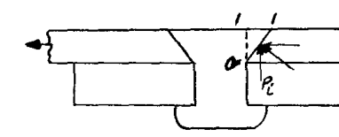

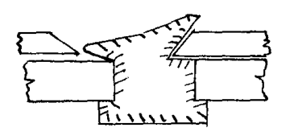

プレス皿穴（ディンプル）型の皿頭リベット接続（図D1.26bおよびcを参照）では、ディンプルによる板同士のかみ合いがあるため、板が結合されていればリベットがなくても荷重を伝達できる場合がある。 このタイプの接合部には明確に定義された支圧面やせん断平面が存在しないため、荷重が伝達されるメカニズムは非常に複雑である。 その結果、設計許容値を確立するには試験に頼らざるを得ない。 表D1.7、表D1.11、および表D1.12は、皿頭リベットの極限強度および降伏強度を示している（参考文献2）。

## D1.22 ブラインドリベット

「ブラインド」リベットという名称は、接合部の片側から完全に設置できるタイプのリベットに与えられており、したがって、接合部の両側へのアクセスを必要とする通常のリベットを打鋲することが不可能または実用的でない場所にほぼ排他的に使用される。 ブラインドリベットには大きく分けて2つのタイプがあり、すなわち、内側またはブラインド側の頭部が機械的に形成されるものと、爆発力によって形成されるものである。

図D1.31はデュポン式爆薬タイプを示し、図32から図34aは機械的に形成される頭部タイプを示している。

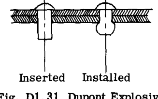

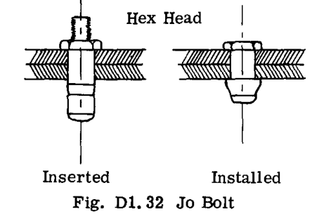

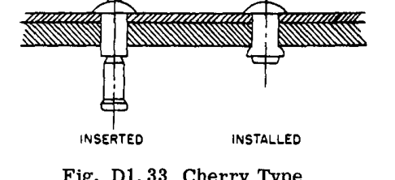

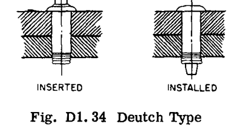

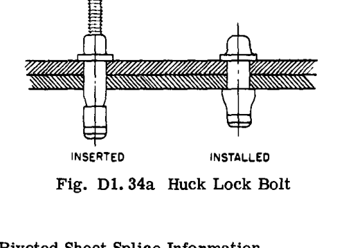

## D1.23 リベット留め板継手に関する情報

リベットやボルトを用いて2枚の板を継ぎ合わせたり接続したりする場合、接合部または接続部は、単一および複数のボルト接続金具ユニットについて詳細に説明したように、様々な方法で破壊する可能性がある。 したがって、リベットのせん断強度、板に対するリベットの支圧、板端部の引きちぎり、およびリベット穴を通る断面の引張をチェックしなければならない。

### 板継手または接続の種類

図D1.35は、様々な種類の板継手を示している。 厚さの異なる2枚の板の間のオフセット重ね継手では、オフセットはより厚い方の材料に設けるべきである。 単一せん断の突合せ継手の場合、突合せストラッププレートの厚さは継ぎ合わされる2枚の板のうち薄い方の板厚と等しくあるべきであり、同様に、二重せん断の突合せ継手の場合、ストラッププレートは同じ厚さであり、かつ継ぎ合わされる薄い方の板厚と等しくあるべきである。

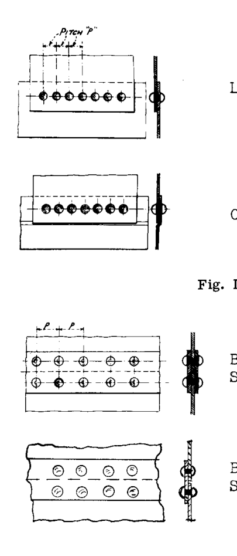

図 D1.35

### 使用すべき適切なリベットサイズ

板の継手にとって最適なリベットに関する厳密な規則を与えることはできない。なぜなら、多くの実際的な考慮事項が通常板継手の設計に関係してくるからである。 小さなリベット、すなわち1/16インチおよび3/32インチ径のものは取り扱いが難しく、構造用リベットとして使用されることはめったにない。 一般的なリベットのサイズは、1/8、5/32、3/16、および1/4インチ径である。 大きなリベットを打鋲する際に板が座屈する可能性があるため、裏打ち構造がない限り、板継手に大きなサイズを使用すべきではない。 構造設計の観点からは、最適な接合部とは、与えられた板に対する許容リベットせん断強度と支圧強度が、実用的な最大リベットサイズに対して実質的に同じになるものである。

### リベット間隔。板端部距離。

文献(1)に示されている許容リベット-板支圧荷重は、リベット径の2倍の端部距離に基づいている。 したがって、一般に、接合部における端部距離は、突出頭リベットの場合はリベット径の2倍、プレスおよび機械皿穴加工された皿頭リベットの場合はリベット径の2.5倍を下回ってはならない。

与えられたサイズのリベットに対する最小ピッチ（同一列内のリベットの中心線間の距離）は、表AおよびBに与えられている値よりも小さくあるべきではない。

### 表 A 突出頭リベットの標準最小間隔

| リベット径 | 1/8 | 5/32 | 3/16 | 1/4 |
| --- | --- | --- | --- | --- |
| 標準最小間隔 | 1/2 | 9/16 | 11/16 | 7/8 |

### 表 B プレスおよび機械皿穴皿頭リベットの標準最小間隔

| リベット径 | 1/8 | 5/32 | 3/16 | 1/4 |
| --- | --- | --- | --- | --- |
| 標準最小間隔 | 11/16 | 27/32 | 1-1/32 | 1-1/4 |

一般に、最小のリベット列間隔は、2つの列内の任意の2つのリベット間の距離が、使用されているリベットサイズに対する最小リベット間隔を下回らないようにすべきである。

### 継手板の引張効率

リベットやボルトによって板を継ぎ合わせる場合、リベット穴によって板材料の一部が切り取られるため、板が弱くなることを意味する。 継ぎ合わされた板の引張強度と継ぎ合わされていない板の引張強度との比を、接合部の板引張効率と呼ぶ。 最小のリベット間隔を使用し、リベットが1列だけの場合、板の効率は約70〜75パーセントになる。 設計者は、より高い効率を目指して努力すべきである。

## D1.24 リベットの使用を含む例題

### 問題 1. トルク管へのホーン接続。

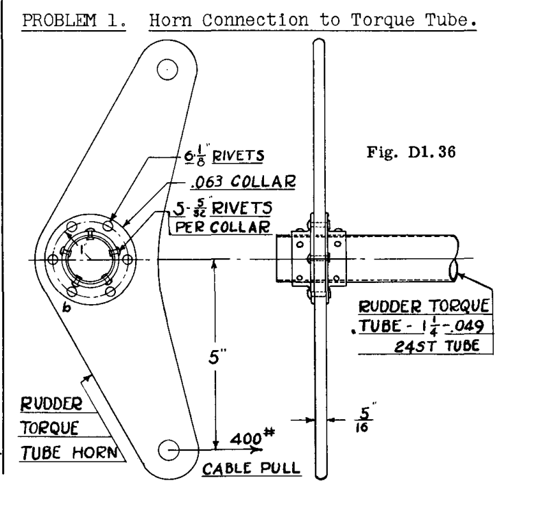

図 D1.36

図D1.36は、小型航空機のラダートルク管の下端へのラダーホーンの取り付けを示している。 ホーンは、ホーンにリベット留めされた2つのカラーによって管に固定され、同様に管にも固定されている。 設計荷重であるケーブル引張力は400 lbであり、これには1.15のフィッティング安全率が含まれている。 リベット材料は 2117-T3 アルミニウム合金である。 ホーンと管は 2024-T3 アルミニウム合金である。 リベット接続の安全余裕（M.S.）を計算する。

#### 解答：

400 lbの水平ケーブル引張力は、管の中心線における等価な力システム、すなわち $400 imes 5 = 2000 \text{ in.lb.}$ のねじりモーメントと、400 lbの水平力に置き換えることができる。

#### カラーのホーンへの取り付けを考慮する：

6本の 1/8 径リベットが二重せん断で使用されている。

ねじりによるリベット1本あたりの荷重 = $2000 / (6 imes 1) = 334 \text{ lb}$ （リベットアームは1インチである）。

水平力によるリベット1本あたりの荷重 = $400 / 6 = 67 \text{ lb}$ 。

最も臨界的なリベットにおける合荷重は、
$$334 + 67 = 401 \text{ lb}$$

リベットせん断における M.S. = $(718 / 401) - 1 = 0.79$

各リベットは、それぞれ厚さが 0.063 である2つのカラーを支持している。 2024-T3 アルミニウム合金材料の 0.063 板に対する 1/8 リベットの支圧強度は、表D1.9およびD1.8から得られる。

表D1.9から、許容支圧応力 $F_{br} = 100,000$ に基づく 0.063 板に対する 1/8 径リベットの支圧強度は 810 lb である。 次に、2024-T3 材料および $e/D$ が 1.5 に対する表D1.8を参照すると、補正係数 0.98 が見つかる。 したがって、支圧強度は $0.98 imes 810 = 794 \text{ lb}$ となる。 各リベットは2つのカラーを支持しているため、リベット1本の支圧強度は $2 imes 794 = 1588 \text{ lb}$ となる。

M.S. = $(1588 / 401) - 1 = 2.96$

#### カラーの管への取り付けを考慮する：

10本の 5/32 径リベットが使用されている。

ねじりによる各リベットの荷重 = $2000 / (10 imes 0.6) = 334 \text{ lb}$ 。 400 lbの水平力は、カラーと管の間の直接の支圧によって受けることができる。

リベットは単一せん断状態にある。 表D1.5から 5/32 リベットの単一せん断強度 = $596 imes 0.996 = 594 \text{ lb}$ 。 （0.996という値は、表D1.5の中央の表からの補正値である。）

M.S. = $(594 / 334) - 1 = 0.78$

表D1.9から、厚さ 0.050 および $F_{br} = 100,000$ に対する 0.049 管壁における支圧強度は 795 lb であり、これを 0.049 に補正すると $(0.049 / 0.050) \times 795 = 780 \text{ lb}$ となる。 2024-T3 管材料および $e/D = 2.0$ に対し、1.24の材料係数を得る。 したがって、管壁におけるリベット1本の支圧強度は $1.24 imes 780 = 967 \text{ lb}$ となる。

M.S. = $(967 / 334) - 1 = 1.9$

### 問題 2.

図D1.37は、6本の 1/4 径リベットによってダブルチャンネルセクションに取り付けられたプレート金具を示している。 設計金具荷重を図に示す。 リベット留め接続について、与えられた設計金具荷重の下での強度をチェックする。

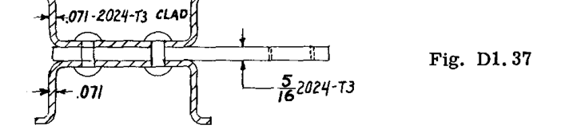

図 D1.37

#### 解答：

与えられた力システムは、リベット群の重心に作用する等価な力システムに置き換えられる。 この力システムは以下で構成される：

$$H_{c.g.} = 8000 \text{ lb}, \quad V_{c.g.} = 3000 \text{ lb}$$
$$M_{c.g.} = 8000 \times 0 + 3000 \times 3 = 9000 \text{ in.lb.}$$

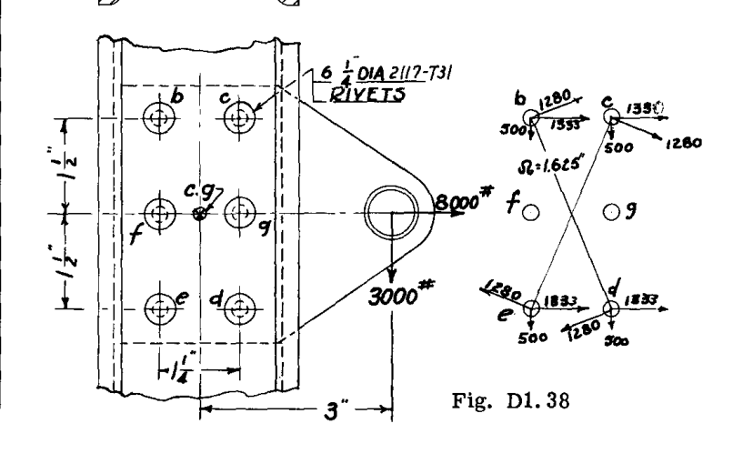

図 D1.38

リベットはすべて同じサイズであるため、すべてのリベットが $H$ および $V$ 荷重に抵抗するのを等しく分担すると仮定される。

$H_{c.g.}$ による各リベットの荷重 = $8000 / 6 = 1333 \text{ lb}$ （ $H$ 方向に右向きに作用）。 $V_{c.g.}$ による各リベットの荷重 = $3000 / 6 = 500 \text{ lb}$ （下向きに作用）。

式(15)から、リベット群に対する $M_{c.g.}$ によるリベットの荷重は $F = M r / I$ に等しい。

$$I = \Sigma r^2 = 1.625^2 \times 4 + 0.625^2 \times 2 = 11.4$$

cとマークされたリベットを考慮する： * $r = 1.625$ = ボルト群の重心へのアーム。 * $F_c = M r / I = (9000 imes 1.625) / 11.4 = 1280 \text{ lb}$ 。

リベットb、d、およびeは重心からリベットcと同じ距離にあるため、これらのボルトに対するモーメント荷重も 1280 に等しくなる。 図D1.38は、リベットb、c、d、およびeにおける $H$ 、 $V$ 、および $M$ 荷重を示している。 リベットfおよびgへのアーム $r$ は 0.625 にすぎないため、モーメントによる荷重はかなり小さくなり、したがってこれらのリベットは限界にはならない。 図D1.38の観察から、リベットcが最大の合荷重を持つリベットであることがわかる。

$$R_c = \sqrt{\left(\Sigma F_H\right)^2 + \left(\Sigma F_V\right)^2}$$
$$\Sigma F_H = 1333 + 1280 \times 1.5 / 1.625 = 2513 \text{ lb}$$
$$\Sigma F_V = -500 - 1280 \times 0.625 / 1.625 = -992 \text{ lb}$$
$$\text{したがって、} R = \sqrt{2513^2 + 992^2} = 2700 \text{ lb}$$

リベットは二重せん断状態にある。 リベット材料は 2117-T31 である。

表D1.5から、単一せん断値は 1760 lb、または二重せん断強度は 3520 lb である。

0.071 2024-T3 被覆チャンネルセクションにおける 1/4 リベットの支圧強度は、表D1.9およびD1.8から $1825 imes 1.20 = 2190$ である。 リベットは2つのチャンネルを支持しているため、リベット1本の支圧強度は $2 imes 2190 = 4380 \text{ lb}$ となる。 リベットのせん断が限界である。

$$M.S. = (3520 / 2700) - 1 = 0.30$$

読者への課題として、リベットfおよびgを 3/16 径に変更し、リベット取り付けが依然として正の安全余裕を示すかどうかを判断せよ（式16を使用）。

### 問題 3.

図D1.39は、示すように2列のリベットを含む重ね継手を示している。 板材料は 2024-T3 被覆であり、リベットは 5/32 径で 2117-T3 材料であり、突出頭型である。

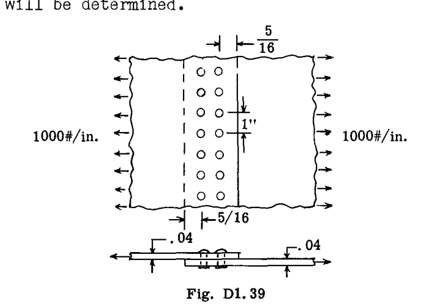

図 D1.39

1.15の金具安全率を含む板の極限設計引張荷重は $1000 \text{ lb./inch}$ である。 制限金具荷重は $2/3 imes 1000 = 667 \text{ lb./in.}$ である。

板継手の安全余裕を決定する。

#### 解答：

解析単位として、リベットピッチの1インチに等しい板幅を使用する。 したがって、1インチ単位あたりの荷重 = 1000 lb である。

#### 穴を通る断面における板の引張をチェックする：

$$P_{t\text{(allow)}} = A F_{tu}$$
$$A = \text{純断面積} = (1 - 0.159) \times 0.04 = 0.0336$$
（0.159 = 5/32 リベットのドリル径、表D1.6）

2024-T3 被覆に対する $F_{tu} = 60,000 \text{ psi}$ 。

$$P_{t\text{(allow)}} = 0.0336 \times 60000 = 2016 \text{ lb}$$
$$M.S. = (2016 / 1000) - 1 = 1.01$$

#### リベットのせん断をチェックする：

リベットは単一せん断状態にあり、仮定した1インチ単位内に2本のリベットが作用している。 表D1.5から、5/32 2117-T3 リベットの単一せん断強度は 596 lb である。 表D1.5の中央の表から、0.04の板厚に対する強度係数は 0.964 である。 したがって、2本のリベットに対して、せん断強度は $2 imes 0.964 imes 596 = 1150 \text{ lb}$ となる。

$$M.S. = (1150 / 1000) - 1 = 0.15$$

#### 0.04 板におけるリベットの支圧をチェックする：

表D1.9から、0.04板に対する 5/32 リベットの $F_{br} = 100,000 \text{ psi}$ に基づく極限支圧強度は 636 lb である。 次に、2024-T3 被覆材料および $e/D$ 比が 2.0 に対する表D1.8を参照すると、補正係数 $K = 1.14$ が見つかる。 したがって、リベットの支圧強度は $1.14 imes 636 imes 2 = 1450 \text{ lb}$ となる。

$$M.S. = (1450 / 1000) - 1 = 0.45$$

#### リベットのせん断アウトをチェックする：

端部距離は 5/16 インチ、すなわち $e/D = 2.0$ であるため、せん断アウト強度は満足できるものである。

### 問題 4.

リベットをソリッド $100^{\circ}$ ディンプル型に変更したと仮定する。 リベットの M.S. はどうなるか。 図D1.27を参照すると、板厚はダブルディンプリングを防ぐようなものであることがわかる。 表D1.11およびD1.12から、0.04板における 5/32 リベットの極限強度および降伏強度として、それぞれ 635 および 506 lbs が得られる。

**注意：** 穴断面を通る板の引張強度をチェックする際、ディンプルリベットのドリルサイズは突出頭型に比べてわずかに大きい。

### 問題 5.

これは、図D1.40に示すような、板-ストリンガータイプの構造におけるリベット荷重を含む典型的な問題である。 点(1)から(10)におけるリベットサイズと間隔を決定する前に、これらの点におけるリベット荷重を知る必要がある。 ウェブおよび外板における方向と大きさのせん断流が図に示されており、単位は lbs. per inch である。 これらの値は、飛行状態の1つにおける結果を表している。 構造設計者は、クリティカルなリベット荷重を得るために、様々な飛行および着陸状態におけるすべてのせん断流を考慮しなければならない。 示されているせん断流には、様々な板パネルにおける斜め引張効果が含まれていると仮定される。

リベット列1から10におけるリベット荷重（lbs./in.）は以下の通りとなる：

#### リベット列(1)：

0.05の垂直ウェブが点(1)で終わっているため、垂直ウェブ内の 1075 lbs./in. のせん断流は、明らかにリベット列(1)のリベットによって反力を受けなければならず、したがってリベット列(1)への荷重は 1075 lbs./in. である。

#### リベット列(2)：

同様の理由により、外板が点(2)で終わっているため、リベット列(2)への荷重はパネル2-3内のせん断流、すなわち 575 lbs./in. に等しい。

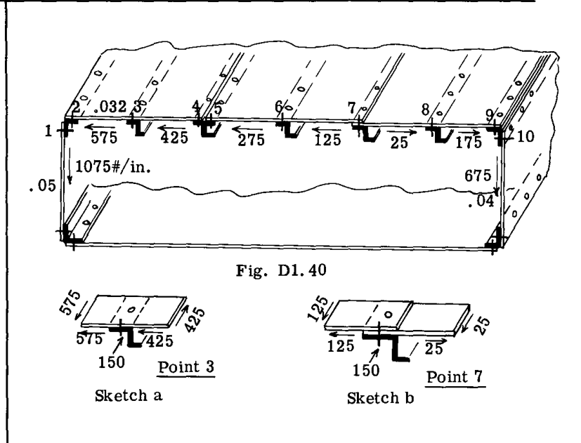

図 D1.40

#### リベット列(3)：

外板は点(3)でストリンガーの上を連続している。 スケッチ(a)は、点(3)における外板とストリンガーのフリーボディ（自由体）を示している。 ストリンガーに平行な力の総和はゼロでなければならないため、ストリンガーに伝達される荷重は 150 lbs./in. であることが観察される。

#### リベット列(4)および(5)：

板がストリンガーの上で終わっているため、リベット列(4)および(5)における荷重はそれぞれ 425 および 275 lbs./in. である。

#### リベット列(6)：

$$\text{リベット荷重} = 275 - 125 = 150 \text{ lbs./in.}$$

#### リベット列(7)：

外板は点(7)でストリンガーの上で重ね継ぎされている。 スケッチ(b)はフリーボディを示している。 つり合いからストリンガーに生じる荷重は150である。 したがって、リベットに対する最悪のせん断荷重は 150 lbs./in. であり、これはパネル6-7内のせん断流に等しいリベットの別の断面におけるせん断 125 lbs./in. よりも大きい。

- リベット列(8)への荷重 = $175 - 25 = 150 \text{ lbs./in.}$
- リベット列(9)への荷重 = $175 \text{ lbs./in.}$
- リベット列(10)への荷重 = $675 \text{ lbs./in.}$

## D1.25 引張状態のリベット

引張状態のリベットを使用する際には、大きな判断が必要である。 「引張状態のリベットは決して使用するな」という一般的な格言がある。 もしこの要求が厳格に守られるならば、通常の航空機を設計することは困難であろう。 例えば、翼の上面の外板は、上向きの吸引空気力のために、外板をストリンガーやリブに固定するリベットに引張を作用させるが、これらの引張荷重はほとんどの場合比較的穏やかである。

引張状態のリベットに関しては、以下の一般的な基準が適用される。

1. リベットへの引張は、引張荷重がリベットの主要なせん断支持目的に対して偶発的である条件に制限されるべきである。 引張成分が偶発的なものであるか主要なものであるかを決定することが困難な場合は、ボルトを使用すべきである。
2. 以下は、リベットが満足できる引張支持媒体とみなされる接合部の例である。
   - 1. 外板のリブやフレームへの取り付け
   - 2. 板の座屈や対角板のしわによってリベットに引張荷重が生じるような、梁フランジやストリンガーへの板パネルの取り付け。
   - 3. 加圧されたナセルまたは胴体上の外板取り付け。
3. 制御ブラケットを支持構造に固定するためにリベットを使用しないこと。
4. アセンブリに荷重の反転がない場合、以下の表に与えられている許容引張荷重を使用することができる。
5. アセンブリに荷重の反転がある場合、リベットへの引張荷重は表の値の25パーセントを超えてはならない。
6. せん断と引張の両方の荷重を受けるリベットは、以下の相互作用式を使用して、複合応力についてチェックされるべきである。

$$R_t^3 + R_s^3 = 1$$

7. 不適切な設置、頭部のひび割れなどによるいずれか1本のリベットの破壊が、リベットによって結合されている構造全体の破壊につながらないように、十分な数のリベットを使用しなければならない。

## D1.26 リベットの引張強度

様々な航空機会社の構造設計マニュアルを参照すると、リベットの引張強度は、せん断や支圧の場合のように標準化されておらず、同一ではないことがわかる。 表A、B、およびCは参考文献(5)から引用したものである。 与えられている値は、他の会社のマニュアルに見られる値に対して保守的なものである。

## 表 D1.11 ソリッド 100° ディンプルリベットの極限強度

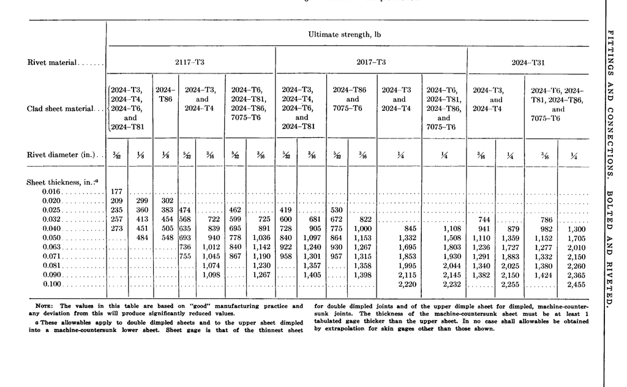

Table D1.11

## 表 D1.12 ソリッド 100° ディンプルリベットの降伏強度

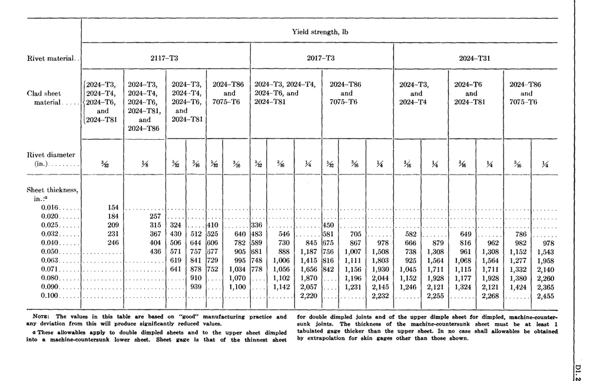

Table D1.12

## 表 A 丸頭リベット (AN470, AN442) 極限引張強度

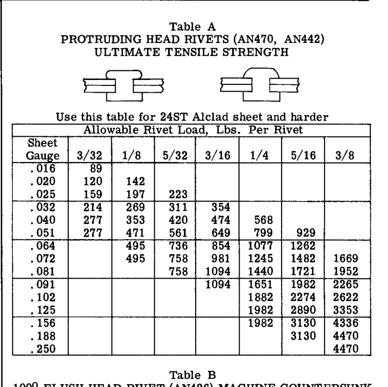

Table A

## 表 B 100° 皿頭リベット (AN426) 機械皿穴ジョイント極限引張強度

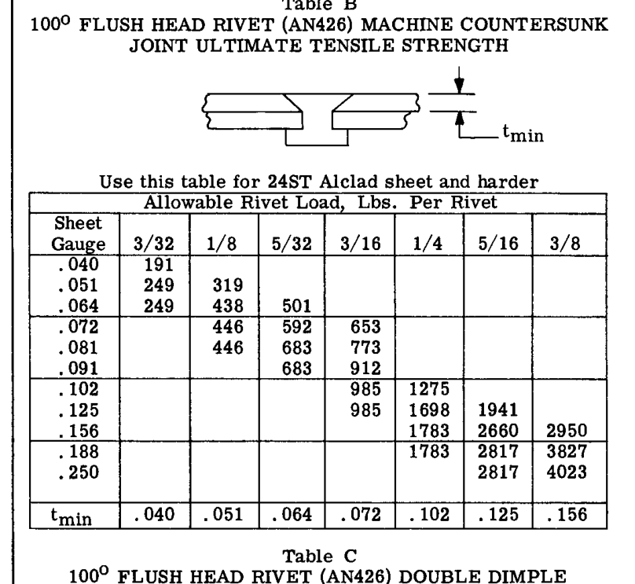

Table B

## 表 C 100° 皿頭リベット (AN426) ダブルディンプル極限引張強度

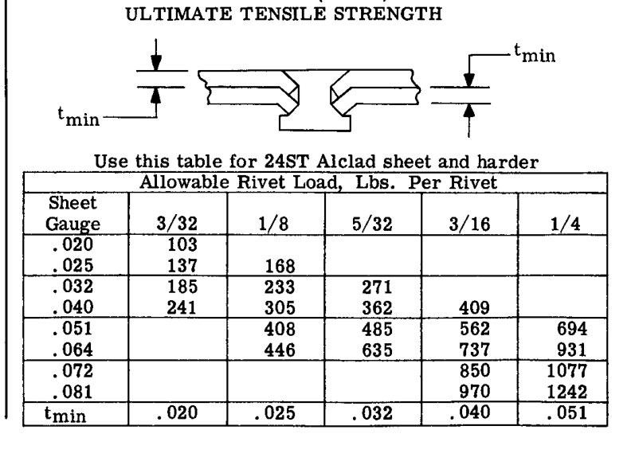

Table C

# 問題

1. 図1に示すようなシングルボルト金具ユニットは、12000 lbs. の軸方向引張の設計金具荷重を受ける。 ピンは直径 3/8 インチのANスチールボルトである。 ブッシングは肉厚 1/16 のスチール製で、 $F_{tu} = 125000$ である。 ラグ材料は 2014-T6 バー、 $F_{tu} = 68000$ である。 金具は衝撃や振動を受けない。 ボルトおよびラグ(A)の強度をチェックし、すべての安全余裕（M.S.）を求めよ。

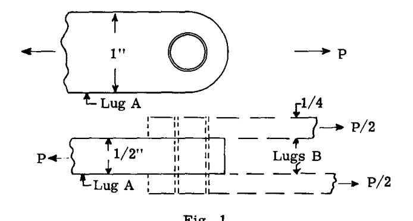

図 1

2. 問題1と同じ金具であるが、設計金具荷重が 10,000 lb の横方向荷重である場合。 強度をチェックし、すべての安全余裕を求めよ。

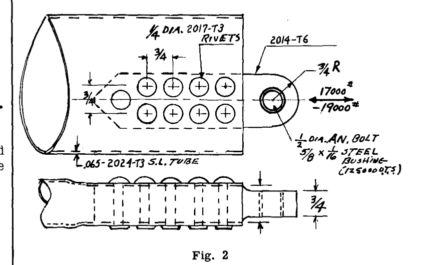

図 2

3. 問題1と同じ金具であるが、ラグ(A)に $45^{\circ}$ で作用する設計金具荷重の値が 11000 lb である場合。 この荷重に対する強度をチェックせよ。
4. 1/2 インチ径のANスチールボルトが、複合されたせん断および引張荷重を受ける。 ボルトへのせん断荷重は 10,000 lbs. であり、引張荷重は 12,000 lbs. である。 この複合荷重の下での安全余裕を求めよ。
5. 標準的なANスチールボルトと、25,000 lbs. の軸方向引張荷重を支持するオスラグを使用して、ヒンジピンを設計せよ。 金具安全率は 1.15 を使用せよ。 スチールブッシングを使用せよ。 衝撃や振動はないものとする。 金具のメス部分のラグは、オスラグの半分の厚さであると仮定せよ。 (1) 2024-T4 アルミニウム合金、および (2) AISI スチール、 $F_{tu} = 180000$ の2つの材料からオスラグを設計せよ。
6. 図2は、流線形支柱用の端部金具を示している。 管は端部でわずかに平らにされ、単純なブロック金具に適合するようになっている。 示されている荷重は設計支柱荷重である。 1.20の金具安全率を使用して、金具ユニット全体の強度をチェックせよ。 衝撃や振動はないものと仮定せよ。
7. 図3は、押し出し（I）セクションの端部における金具ユニットを示している。 (I)セクションのウェブは外側に延びて金具ラグの一部を形成しており、これはスチール製の金具プレートによって補強されている。 45000 lb の設計荷重について金具の強度をチェックせよ。 1.15の金具安全率を使用せよ。

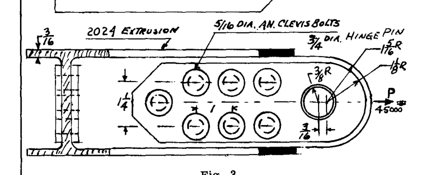

図 3

8. 図4は、典型的な梁端部-シングルピン金具ユニットを示している。 金具プレートは、示すようなリベットパターンによって梁セクションに取り付けられている。 図に示されている荷重は適用荷重である。 適用荷重に対する安全率 1.5、および金具安全率 1.2 を使用して、梁セクションへの金具プレートのリベット取り付けの安全余裕を決定せよ。

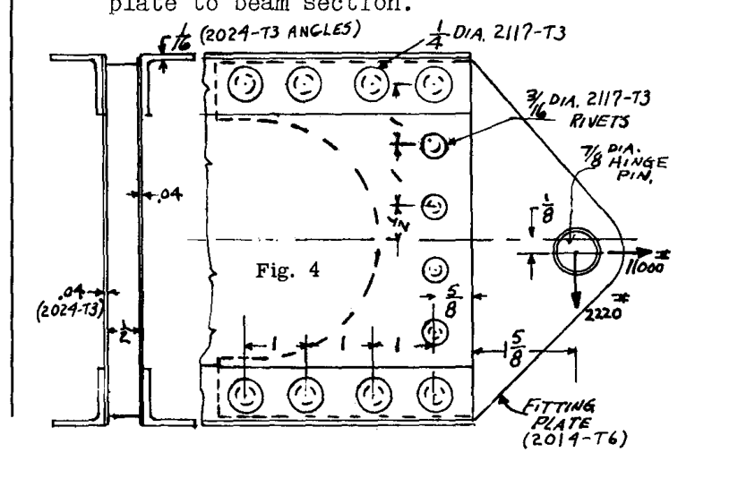

図 4

9. 図5は、4本の 1/4” 径ANスチールボルトによって支持構造に取り付けられたフラップヒンジ金具を示している。 ボルトは二重せん断状態にある。 示すように作用する 3500 lbs. の荷重に対して、せん断および支圧における最も臨界的なボルトをチェックせよ。 金具材料は 2014-T3 である。

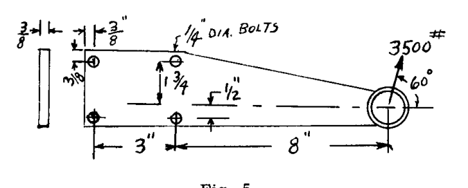

図 5

10. 図6の偏心荷重を受けるマルチボルト金具において、示すように作用する 24000 lbs. の荷重に抵抗する際の、5本のANスチールボルトのそれぞれにおける合荷重を決定せよ。

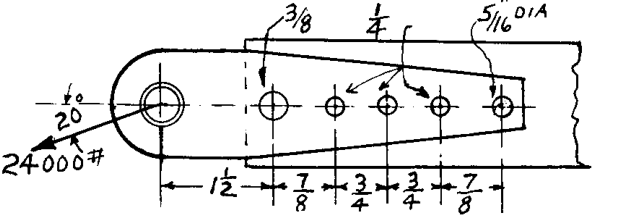

図 6

11. 図7において、金具は4本の 1/4 径ANスチールボルトによって胴体フレームに取り付けられている。 設計金具荷重は示す通りである。 最も臨界的なボルトにおける安全余裕を決定せよ。 複合された引張およびせん断応力に対する式を得るために、図D1.4を使用せよ。

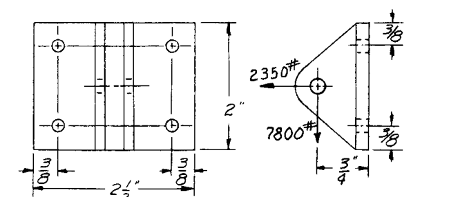

図 7

12. 図8において、示すように 3000 lbs. の極限金具設計荷重を支持するために必要な 2017-T3 リベットのサイズを求めよ。 金具プレートは厚さ 1/8 のスチール、 $F_{tu} = 95000$ であり、 2024-T3 チャンネルフレームは厚さ .081 インチである。

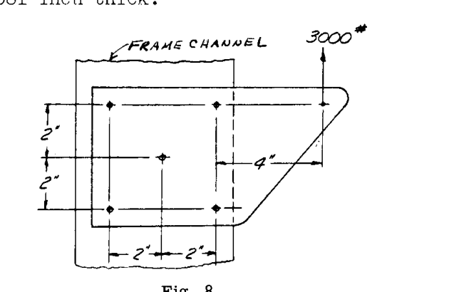

図 8

13. .051 被覆 2024-T6 および突出頭タイプのリベットに対する、最も軽量な重ね板継手を設計せよ。 板における設計引張荷重 = $2350 \text{ lb./in.}$ とする。 接合部のすべての詳細を与えよ。
14. ダブルディンプルリベットを使用するように、問題13の設計をやり直せ。

## 参考文献

1. ANC-5. Strength of Metal Aircraft Elements. March, 1955.
2. Military Handbook MIL-HDBK-5. August, 1962. Metallic Materials and Elements for Flight Vehicle Structures.
3. Cozzone, Melcon, and Hoblit: Analysis of Lugs and Shear Pins Made of Aluminum and Steel Alloys. Product Engineering Vol. 21, May, 1950.
4. Melcon and Hoblit: “Developments in the Analyses of Lugs and Pins.” Product Engineering. June, 1953.
5. Martin Co. Structures Manual.
6. Various Structural Manuals of Various Aircraft Companies.